# test_report

GP

Collaborator

March 16, 2021

Abstract

This is our abstract

It consists of two paragraphs.

# Header 1

Biggest

## Header 2

Big

### Header 3

Pretty big

#### Header 4

Bold face header

# Intro to RMd Formatting

Here is an example of **bold** text, **bold** Here is an example of *italic* text, *italic* Here is an example of *bold italic* text, *bold italic* What about superscripts? x<sup>2</sup> subscripts x<sub>0</sub> underline strikethrough

Line 1  
Line 2

Line 1  
Line 2

* `<br>` starts a new line, it doesn't start a new paragraph

Topic 1. Paragraph

Topic 2. More stuff

Topic 3. Two spaces and two lines

Here is a sentence with a footnote[^1].This sentence follows footnote[^2].

This is intro of doc from important person in block quotes.

> This is our important quote.

> Second section of quote from *really* important person.

> > Nested quote.

Here are our lists for a roadmap:

1. Item 1
2. Item 2
3. Item 3

Numbers sequence doesn't matter

1. Item 1
2. Item 2
3. Item 3

Symbol lists

- Item 1
- Item 2
- Item 3

A differnt symbol

- Item 1
- Item 2
- Item 3

Sublists

1. Item 1
   1. Subitem 1
2. Item 2
   2. Subitem 2
3. Item 3
   3. Subitem 3

We can include blockquots within our lists

> This is a super important list
> 1. Item 1
> 2. Item 2
> 3. Item 3

If we want to provide further descrip of items

1. Item 1

   This is our paragraph for Item 1.
2. Item 2

   This is our paragraph for Item 2.
3. Item 3

   > This is our blockquote for Item 3.

Demo of a messy table

| Col 1 | Col 2 | Col 3 | Col 4 |
| --- | --- | --- | --- |
| 1 | 2 | 3 | 4 |
| 5 | 6 | 7 | 8 |

Demo of a clean table

| Col 1 | Col 2 | Col 3 | Col 4 |
| --- | --- | --- | --- |
| 1 | 2 | 3 | 4 |
| 5 | 6 | 7 | 8 |

Let's include a few links that are *important* https://rmarkdown.rstudio.com/lesson-1.html or with hyperlinks [name of link](https://rmarkdown.rstudio.com/lesson-1.html)

# Intro to Code Chunks

Figure caption

```r
x = rnorm(n=100, mean=5, sd=1)
y = 2 + 2*x + rnorm(n=100)
```

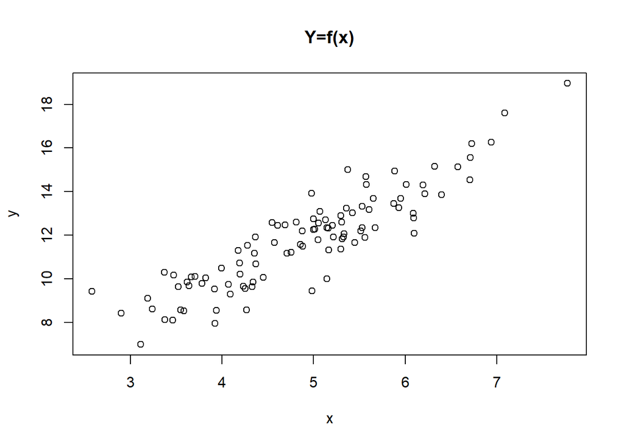

```r
plot(x, y, main='Y=f(x)')
```

Our response variabe $y$ is distributed $\mathcal{N}(\mu, \sigma^2)$, where
$$\begin{align}
\mu &= 2 + 2E[x] + E[e] \\
\sigma^2 &= 2^2Var[x] + 1^2Var[e] + 2*2*1Cov[x,e]
\end{align}$$

$$y = f(x)$$

Our small sample provides $\mu=$ 11.7969675 and $\sigma^2=$ 4.9248108

Our small sample provides $\mu=$ 11.8 and $\sigma^2=$ 4.92

Demo of a `R` output table

[output not shown]

# Bigger and Better Data

```r
library(tidyverse)
df_all = read_csv('data/daily_bike_data.csv')
dftemp = df_all %>%
  select(cnt, temp)
```

```r
ss_dftemp = sapply(dftemp, function(j)
                            c(mean(j), min(j), max(j), sd(j))) %>%
  data.frame() %>%
  round(digits=2)

row.names(ss_dftemp) = c("mean", "min", "max", "sd")

ss_dftemp %>% kable(caption="Summary Statistics")
```

Summary Statistics

|  | cnt | temp |
| --- | --- | --- |
| mean | 4504.35 | 0.50 |
| min | 22.00 | 0.06 |
| max | 8714.00 | 0.86 |
| sd | 1937.21 | 0.18 |

Here is a graphic relationship beteween `cnt` and `temp`

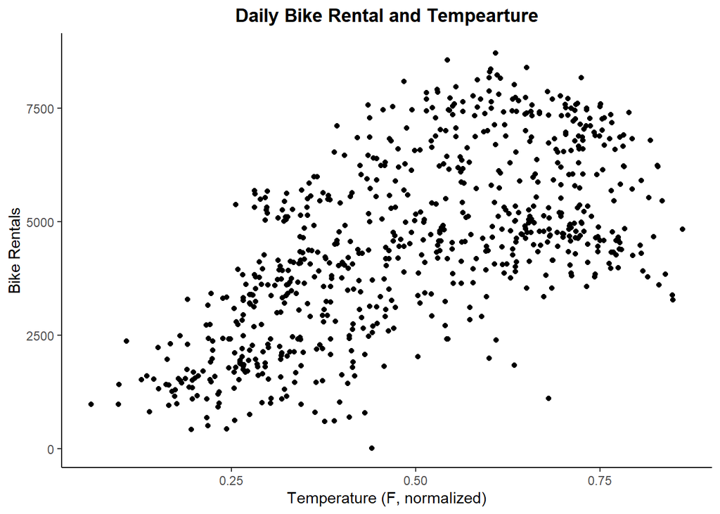

```r
ggplot(data=dftemp, aes(x=temp, y=cnt)) +
  theme_classic() +
  geom_point() +
  labs(title='Daily Bike Rental and Tempearture',
       x='Temperature (F, normalized)',
       y='Bike Rentals') +
  theme(plot.title=element_text(face='bold', hjust=0.5))
```

```r
dftemp = dftemp %>%
  mutate(temp2 = temp^2)

# construct linear model for slope association
mod1 = lm(cnt ~ temp, data=dftemp)

# construct basis expansion for curvature question
# mod2 = lm(cnt ~ temp + temp2, data=dftemp)
mod2 = lm(cnt ~ ., data=dftemp)

# get model predictions
pred_mod1 = predict(mod1, dftemp['temp'])
pred_mod2 = predict(mod2, dftemp[c('temp', 'temp2')])
# pred_mod2 = predict(mod2, dftemp[, -1])

# update dataframe
pred_dftemp = dftemp %>%
  mutate(cnt_mod=pred_mod1, cnt_mod2=pred_mod2)
```

Presented below are model summary statistics

```r
summary(mod1)$coefficient %>%
  kable(caption="Model 1 Summary (Dep. cnt)", digits=3)
```

Model 1 Summary (Dep. cnt)

|  | Estimate | Std. Error | t value | Pr(>\|t\|) |
| --- | --- | --- | --- | --- |
| (Intercept) | 1214.642 | 161.164 | 7.537 | 0 |
| temp | 6640.710 | 305.188 | 21.759 | 0 |

```r
#OR
broom::tidy(mod2) %>%
  kable(caption="Model 2 Summary (Dep. cnt", digits=3)
```

Model 2 Summary (Dep. cnt

| term | estimate | std.error | statistic | p.value |
| --- | --- | --- | --- | --- |
| (Intercept) | -1901.956 | 382.391 | -4.974 | 0 |
| temp | 21406.931 | 1685.202 | 12.703 | 0 |
| temp2 | -15055.025 | 1692.522 | -8.895 | 0 |

Here is what models look like with data

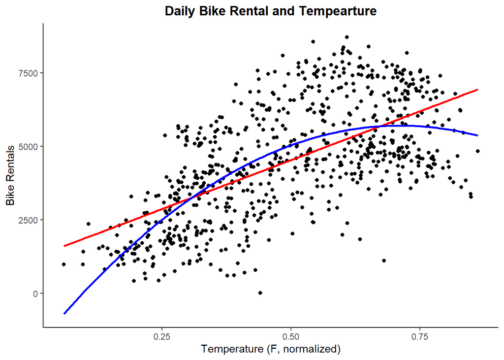

```r
ggplot(data=pred_dftemp, aes(x=temp, y=cnt)) +
  theme_classic() +
  geom_point() +
  geom_line(aes(x=temp, y=cnt_mod), color='red', size=1) +
  geom_line(aes(x=temp, y=cnt_mod2), color='blue', size=1) +
  labs(title='Daily Bike Rental and Tempearture',
       x='Temperature (F, normalized)',
       y='Bike Rentals') +
  theme(plot.title=element_text(face='bold', hjust=0.5))
```

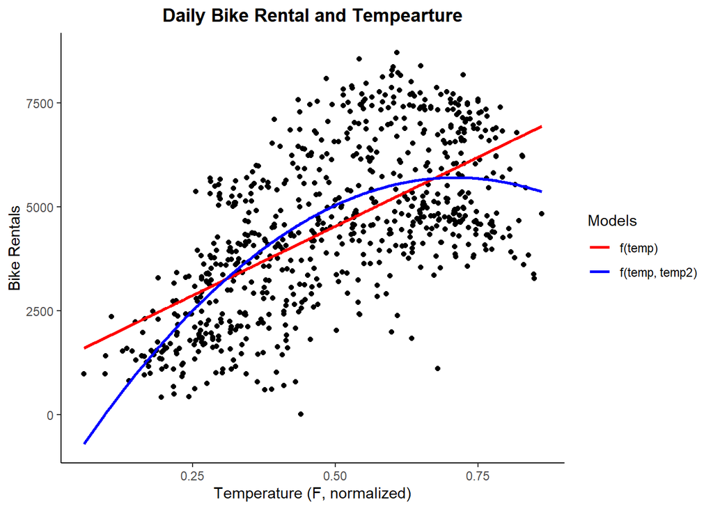

```r
ggplot(data=pred_dftemp, aes(x=temp, y=cnt)) +
  theme_classic() +
  geom_point() +
  geom_line(aes(x=temp, y=cnt_mod, color='f(temp)'), size=1) +
  geom_line(aes(x=temp, y=cnt_mod2, color='f(temp, temp2)'), size=1) +
  labs(title='Daily Bike Rental and Tempearture',
       x='Temperature (F, normalized)',
       y='Bike Rentals') +
  theme(plot.title=element_text(face='bold', hjust=0.5)) +
  scale_color_manual(name='Models', values=c('f(temp)'='red', 'f(temp, temp2)'='blue'))
```

[^1]: Here is our first footnote.
[^2]: Footnote the second